1. 東京城南地区および川崎市の賃貸物件データ(rent-jonan-kawasaki.csv)を用いて以下の表を作成したい。

```r
# 下準備
setwd("/Users/ebuchitsukasa/Desktop/university/seminar/seminar2autumn")
library("dplyr")
dataf <- read.csv("/Users/ebuchitsukasa/Desktop/university/seminar/seminar2autumn/data-script/chapter2/rent-jonan-kawasaki.csv")
```

(1)鉄道路線別オートロック付き物件の比率

```r
prop.table(table(dataf$autolock, dataf$line), margin=2)
```

```
##
##              jr    keikyu     tokyu
##   NO  0.6292683 0.6705882 0.6486486
##   YES 0.3707317 0.3294118 0.3513514
```

```r
prop.table(table(dataf$line, dataf$autolock), margin=1)
```

```
##
##                 NO       YES
##   jr     0.6292683 0.3707317
##   keikyu 0.6705882 0.3294118
##   tokyu  0.6486486 0.3513514
```

(2)鉄道沿線別の平均賃貸料、平均築年数、平均専有面積

```r
# p54 group_byを使用
dataf %>%
  dplyr::group_by(line) %>%
    summarize(
      avg_rent = mean(rent),
      avg_age = mean(age),
      avg_floor = mean(floor),
    )
```

```
## # A tibble: 3 × 4
##   line   avg_rent avg_age avg_floor
##   <chr>     <dbl>   <dbl>     <dbl>
## 1 jr         9.16    12.9      35.4
## 2 keikyu     8.77    11.5      33.4
## 3 tokyu      9.53    14.0      29.1
```

```r
# xtabsを使う方法もあるらしい
```

```r
dataf <- dataf %>% dplyr::mutate(
  r_category=
    case_when(
      rent<0 ~ "-03",
      rent>=3&rent<6 ~ "03-06",
      rent>=6&rent<9 ~ "06-09",
      rent>=9&rent<12 ~ "09-12",
      rent>=12&rent<15 ~ "12-15",
      rent>=15&rent<18 ~ "15-18",
    )
)

table(dataf$r_category)
```

```
##
## 03-06 06-09 09-12 12-15 15-18
##    28   318   126    66    37
```

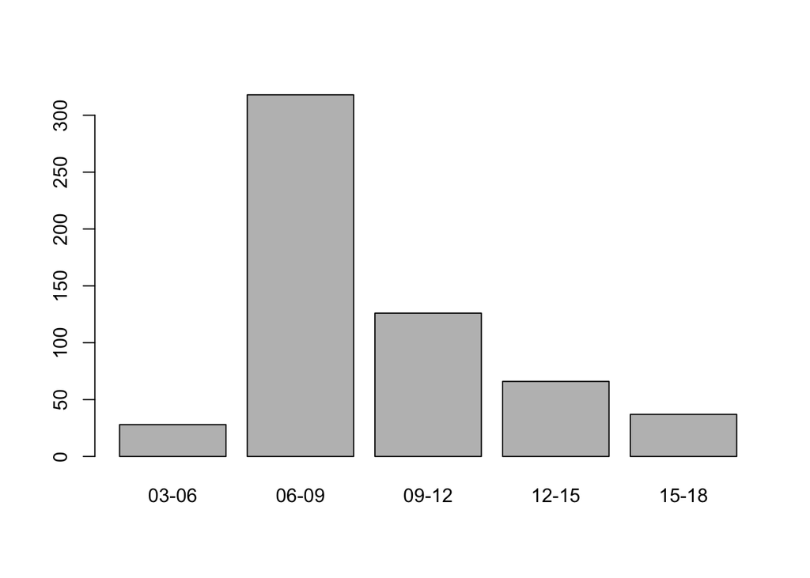

```r
barplot(table(dataf$r_category))
```

```r
# 相関係数行列
dataf <- dataf %>% dplyr::mutate(
  rent_total=rent+service,
  rent_per_square_meter=rent/floor,
  distance=walk+bus,
)

dataf_cor <- dataf %>% dplyr::select(rent_total, rent_per_square_meter, distance)

cor(dataf_cor, use="pairwise.complete.obs")
```

```
##                        rent_total rent_per_square_meter    distance
## rent_total             1.00000000            -0.1447865 -0.02012121
## rent_per_square_meter -0.14478655             1.0000000 -0.32547272
## distance              -0.02012121            -0.3254727  1.00000000
```

2. 東京大学社会科学研究所附属社会調査・データアーカイブ研究センターは、東大社研若年者パネル調査を実施しているが、そのデータをもとにした擬似データを公開しています(非制限擬似データ)。東大社研若年者パネル調査は、2006年12月末現在で20歳から34歳のいわゆる「若年層」を追跡した調査です。非制限擬似データは 2007年の灯台社研若年者パネル調査から1000ケースを無作為抽出した上で、変数を大幅に減らし、回答には無作為ノイズを混入させて割くせされた教育演習用のデータです。このデータを使って以下の変数、および表を作成してみましょう。

```r
# 下準備

dataf2 <- read.csv("/Users/ebuchitsukasa/Desktop/university/seminar/seminar2autumn/data-script/chapter2/u001/u001.csv")
```

(1)調査票の学歴に関連する質問項目ZQ23AとZQ24を参照して、大卒・大学院卒なら”univ”、それ以外なら”others”の変数、univを作成せよ。また、支持政党に関する質問項目ZQ42を参照しながら自民党支持なら”LDP”、そうでなければ”others”をとる変数LDPを作成せよ。また、大卒・院卒とそれ以外で、自民党を支持する人の比率を計算せよ。

```r
# 2.1 変数の作成、比率の計算

dataf2 <- dataf2 %>% dplyr::mutate(
  univ=
    case_when(
      ZQ23A==5|ZQ23A==6 ~ "univ",
      .default = "others",
    ),
  LDP=
    case_when(
      ZQ42==1 ~ "LDP",
      .default = "others",
    )
)

prop.table(table(dataf2$univ, dataf2$LDP), margin=1)
```

```
##
##                LDP    others
##   others 0.1768707 0.8231293
##   univ   0.1771845 0.8228155
```

(2)「普段収入になる仕事をしている人」(ZQ03==1)かつ「既婚(配偶者)」(ZQ50==2)の「男性」(sex==1)に限定したデータフレームを作成し、大卒・院卒とそれ以外で家事をする人の比率を比べたい。家事についてはZQ54A~ZQ54Dに注目して「食事の用意」、「選択」、「家の掃除」「日用品・食用品の買い物」を「毎日する」人とそれ以外の人に分けて、大卒・院卒×家事の実施の有無の比率の表を作成せよ。

```r
# 限定したデータフレームの作成
conditional_dataf2 <- dataf2 %>% dplyr::filter(
  ZQ03==1&ZQ50==2&sex==1
)

conditional_dataf2 <- conditional_dataf2 %>% dplyr::mutate(
  household_category=case_when(
    ZQ54A==1&ZQ54B==1&ZQ54C==1&ZQ54D==1 ~ "every day",
    .default = "others",
  )
)

# 比率の計算
prop.table(
  table(conditional_dataf2$univ, conditional_dataf2$household_category),
  margin=1
)
```

```
##
##          every day    others
##   others 0.1097561 0.8902439
##   univ   0.1506849 0.8493151
```